# HW904104778

## Q1

For calculating profit in this question I subtracted Close value of last row in the interval from Open value from first row in the interval. Then I calculated the biggest profit in one year, two year and five year for every company and then select maximum of them for every sector.

```r
file_names <- list.files('~/Downloads/class_data/stock_dfs/') %>% str_replace('.csv', '')
file_paths <- list.files('~/Downloads/class_data/stock_dfs/', full.names = TRUE)

constituents <- read.csv('~/Downloads/class_data/constituents.csv')

maxyearprofits <- data.frame()
for (i in (1:length(file_paths))){
  data <- read_csv(file_paths[i]) %>% select(Date, Close, Open)
  data <- data %>% mutate(year = substring(as.character(data$Date),1,4))
  maxyearprofit <- data %>% group_by(year) %>% summarise(totalyearprofit = last(Close) - first(Open)) %>% top_n(totalyearprofit, n = 1)
  data <- data %>% mutate(twoyear = (as.numeric(year) - as.numeric(first(year))) %/% 2)
  data <- data %>% mutate(fiveyear = (as.numeric(year) - as.numeric(first(year))) %/% 5)
  maxtwoyearprofit <- data %>% group_by(twoyear) %>% summarise(totaltwoyearprofit = last(Close) - first(Open)) %>% top_n(totaltwoyearprofit, n = 1)
    maxfiveyearprofit <- data %>% group_by(fiveyear) %>% summarise(totalfiveyearprofit = last(Close) - first(Open)) %>% top_n(totalfiveyearprofit, n = 1)
  maxyearprofits <- rbind(maxyearprofits, data.frame(file_names[i], maxyearprofit, maxtwoyearprofit, maxfiveyearprofit))
}


colnames(maxyearprofits)[1] <- "Symbol"
maxyearprofits<- maxyearprofits %>% inner_join(constituents, by = "Symbol" )
oneyear <- maxyearprofits %>% group_by(Sector) %>% filter(totalyearprofit == max(totalyearprofit)) %>% select(Sector, totalyearprofit,Name)
twoyear<- maxyearprofits %>% group_by(Sector) %>% filter(totaltwoyearprofit == max(totaltwoyearprofit))%>% select(Sector, totaltwoyearprofit,Name)
fiveyear<-maxyearprofits %>% group_by(Sector) %>% filter(totalfiveyearprofit == max(totalfiveyearprofit))%>% select(Sector, totalfiveyearprofit,Name)
oneyear
```

```
## # A tibble: 11 x 3
## # Groups:   Sector [11]
##    Sector                     totalyearprofit Name
##    <fct>                                <dbl> <fct>
##  1 Consumer Discretionary               363.  Amazon.com Inc.
##  2 Industrials                           92.3 Acuity Brands Inc
##  3 Financials                           170.  CME Group Inc.
##  4 Utilities                             41.7 Duke Energy
##  5 Real Estate                          103.  Equinix
##  6 Information Technology               401.  Alphabet Inc Class C
##  7 Health Care                          226.  Intuitive Surgical Inc.
##  8 Materials                             86.9 Martin Marietta Materials
##  9 Energy                                74.6 Pioneer Natural Resources
## 10 Consumer Staples                      44.3 Constellation Brands
## 11 Telecommunication Services            11.3 AT&T Inc.
```

```r
twoyear
```

```
## # A tibble: 11 x 3
## # Groups:   Sector [11]
##    Sector                     totaltwoyearprofit Name
##    <fct>                                   <dbl> <fct>
##  1 Consumer Discretionary                  277.  Amazon.com Inc.
##  2 Financials                              317.  CME Group Inc.
##  3 Real Estate                             125.  Equinix
##  4 Utilities                                50.4 Entergy Corp.
##  5 Information Technology                  468.  Alphabet Inc Class C
##  6 Industrials                              90.0 Grainger (W.W.) Inc.
##  7 Consumer Staples                         81.1 Monster Beverage
##  8 Materials                               104.  PPG Industries
##  9 Energy                                   92.2 Pioneer Natural Resources
## 10 Health Care                             267.  Regeneron
## 11 Telecommunication Services               17.1 AT&T Inc.
```

```r
fiveyear
```

```
## # A tibble: 11 x 3
## # Groups:   Sector [11]
##    Sector                     totalfiveyearprofit Name
##    <fct>                                    <dbl> <fct>
##  1 Industrials                              176.  Acuity Brands Inc
##  2 Consumer Discretionary                   460.  AutoZone Inc
##  3 Financials                               471.  CME Group Inc.
##  4 Consumer Staples                          82.6 Costco Wholesale Corp.
##  5 Utilities                                 66.3 Duke Energy
##  6 Real Estate                              129.  Equinix
##  7 Information Technology                   812.  Alphabet Inc Class C
##  8 Energy                                    99.5 Pioneer Natural Resourc…
##  9 Health Care                              386.  Regeneron
## 10 Materials                                201.  Sherwin-Williams
## 11 Telecommunication Services                13.4 Verizon Communications
```

## Q2

According to p-value of t-test we can say that 13th of month does not have any effect on profit.

```r
thirtheen <- data.frame()
notthirteen <- data.frame()
for (i in (1:length(file_paths))){
  data <- read_csv(file_paths[i]) %>% select(Date, Close, Open)
  data <- data %>% mutate(day = substring(as.character(data$Date),9,10))
  thirtheen <- rbind(thirtheen, data %>% filter(day == "13"))
  notthirteen <-rbind(thirtheen, data %>% filter(day != "13"))
}
thirtheen <- thirtheen %>% mutate(profit = Close - Open)
notthirteen <- notthirteen %>% mutate(profit = Close - Open)
t.test(thirtheen$profit, notthirteen$profit)
```

```
##
##  Welch Two Sample t-test
##
## data:  thirtheen$profit and notthirteen$profit
## t = 0.029275, df = 131980, p-value = 0.9766
## alternative hypothesis: true difference in means is not equal to 0
## 95 percent confidence interval:
##  -0.02112412  0.02176471
## sample estimates:
##  mean of x  mean of y
## 0.02103613 0.02071583
```

```r
hchart(density(thirtheen$profit), type = "area",name = "13th of month profit") %>% hc_add_series(density(notthirteen$profit), type = "area",name = "not 13th of month profit")
```

[interactive chart not shown]

## Q3

It is for 13th of October of 2008 that according to google was simultaneous with financial crisis.

```r
joinedall <- data.frame()
for (i in (1:length(file_paths))){
  data <- read_csv(file_paths[i]) %>% select(Date, Volume)
  data$Volume[1:2]
  m = c(0, data$Volume[1:length(data$Volume)-1])
  diff <- data$Volume - m
  data <- cbind(data, diff)

  joinedall <- rbind(joinedall,data %>% select(Date, diff))
}

joinedall %>% group_by(Date) %>% summarise(sum = sum(abs(diff))) %>% top_n(sum, n = 1)
```

```
## # A tibble: 1 x 2
##   Date              sum
##   <date>          <dbl>
## 1 2008-10-13 3353445300
```

## Q4

according to mean square error value the best value for k is 9.

```r
apple <-  read.csv('~/Downloads/class_data/stock_dfs/AAPL.csv') %>% select(Open)
apple <- apple %>%  mutate(n = c(1:length(apple$Open)))
for (k in (1:10)){
  print(k)
  left <- length(apple$Open) %% k
  newOpen <- apple$Open[1:(length(apple$Open) - left)]
  df <- as.data.frame(split(newOpen, 1:k))
  if (k != 1){
      Y <- apple %>% filter(n %% k == 1 & n != 1)  %>% select(Open)
      if (nrow(df) > nrow(Y)){
        df <- df[1:nrow(Y),]
      }
      df <- cbind(df, Y)
      print(mean(summary(lm(Open~., data = df))$residuals^2))
  }
  if(k == 1){
    df <- df[1:nrow(apple)-1,]
    df <- cbind(df, apple$Open[2:nrow(apple)])
      df <- data.frame(df)

      print(mean(summary(lm(V2~., data = df))$residuals^2))
  }
}
```

```
## [1] 1
## [1] 96.1891
## [1] 2
## [1] 25.5197
## [1] 3
## [1] 18.01915
## [1] 4
## [1] 23.57744
## [1] 5
## [1] 17.45885
## [1] 6
## [1] 18.10213
## [1] 7
## [1] 24.35628
## [1] 8
## [1] 17.96027
## [1] 9
## [1] 17.09445
## [1] 10
## [1] 17.22872
```

## Q5

3 first principal components cover 80 percent of variance.

```r
firstdata <- read_csv(file_paths[1]) %>% select(Date, Open)
colnames(firstdata)[2] <- file_names[1]
for (i in 2:length(file_paths)){
    data <- read_csv(file_paths[i]) %>% select(Date, Open)
    colnames(data)[2] <- file_names[i]
    firstdata <- inner_join(firstdata,data,by = "Date")
}
```

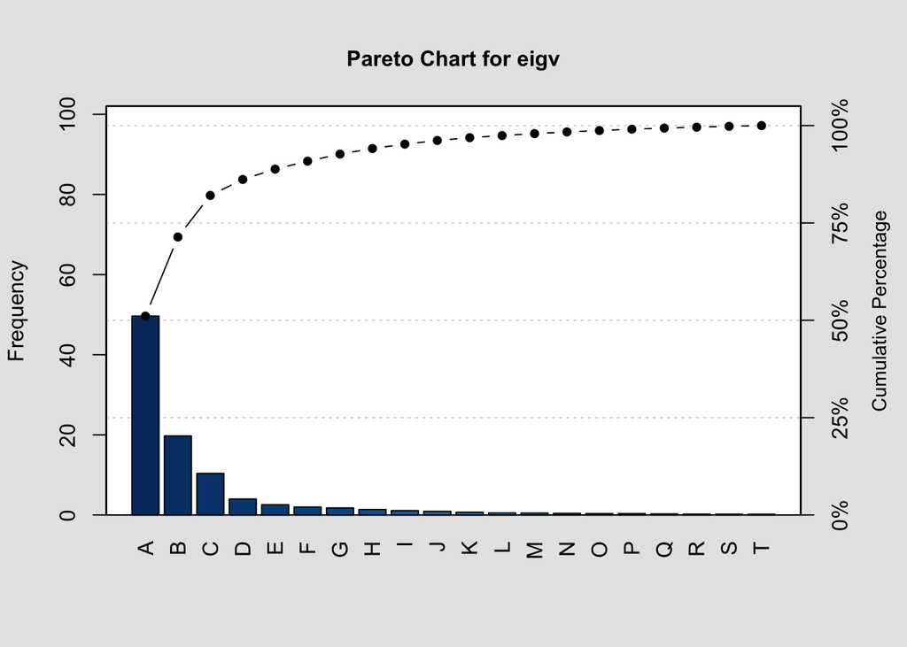

```
##
## Pareto chart analysis for eigv
##       Frequency   Cum.Freq.  Percentage Cum.Percent.
##   A  49.6400000  49.6400000  51.0752135   51.0752135
##   B  19.7400000  69.3800000  20.3107316   71.3859451
##   C  10.3800000  79.7600000  10.6801111   82.0660562
##   D   3.9900000  83.7500000   4.1053606   86.1714168
##   E   2.5700000  86.3200000   2.6443050   88.8157218
##   F   1.9900000  88.3100000   2.0475358   90.8632575
##   G   1.7700000  90.0800000   1.8211750   92.6844326
##   H   1.3800000  91.4600000   1.4198992   94.1043317
##   I   1.1000000  92.5600000   1.1318037   95.2361354
##   J   0.9100000  93.4700000   0.9363103   96.1724457
##   K   0.7000000  94.1700000   0.7202387   96.8926844
##   L   0.5300000  94.7000000   0.5453236   97.4380080
##   M   0.4800000  95.1800000   0.4938780   97.9318860
##   N   0.4200000  95.6000000   0.4321432   98.3640292
##   O   0.3500000  95.9500000   0.3601194   98.7241486
##   P   0.3400000  96.2900000   0.3498302   99.0739788
##   Q   0.2700000  96.5600000   0.2778064   99.3517852
##   R   0.2300000  96.7900000   0.2366499   99.5884350
##   S   0.2100000  97.0000000   0.2160716   99.8045066
##   T   0.1900000  97.1900000   0.1954934  100.0000000
```

```r
pcacmp <- prcomp(firstdata[,2:506], center = T, scale. = T)
eigv = round(pcacmp$sdev^2/sum(pcacmp$sdev^2)*100, 2)
eigv <- eigv[1:20]
qcc::pareto.chart(eigv)
```

## Q6

```r
alldata <- data.frame()
for (i in 1:length(file_paths)){
    data <- read_csv(file_paths[i])
    data <- data %>% mutate(Symbol = file_names[i])
    alldata <- rbind(alldata, data)
}
alldata <- alldata %>% select(Symbol, Open,Date) %>% inner_join(constituents, by = "Symbol") %>% select( Sector, Open,Date) %>% group_by(Sector, Date) %>% summarise(mean = mean(Open))
```

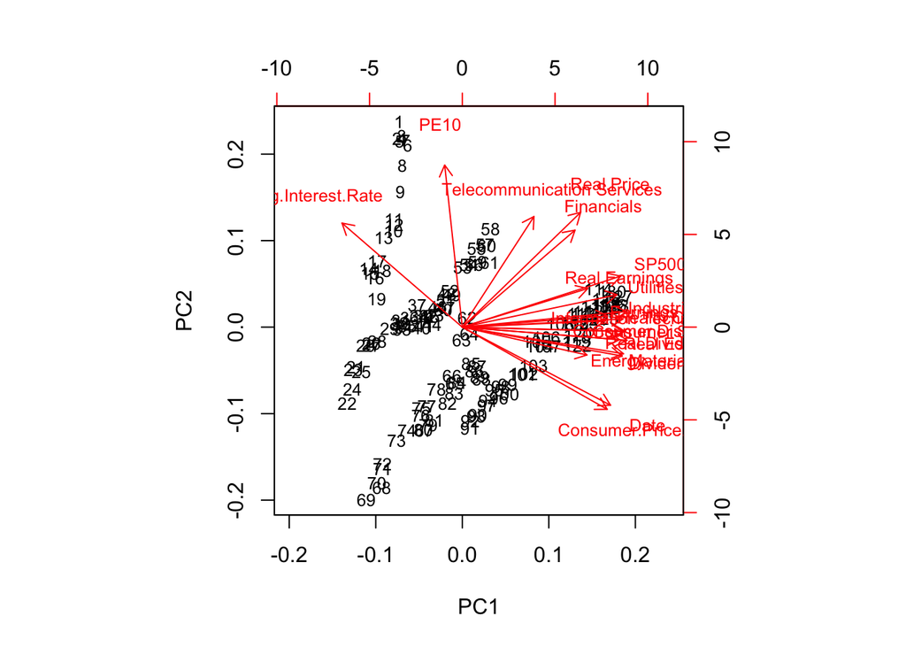

```r
alldata <- dcast(alldata, Date ~ Sector)

indexes <- read.csv('~/Downloads/class_data/indexes.csv')
indexes$Date <- as.Date(indexes$Date)

joinedalldata <- inner_join(indexes, alldata, by = "Date")
joinedalldata$Date <- as.numeric(joinedalldata$Date)
pca <- prcomp(joinedalldata, center = T, scale. = T)
biplot(pca, cex = 0.8)
```

## Q7

Using first principal component is not better than using previous Open values.

```r
Apple <- read.csv('~/Downloads/class_data/stock_dfs/AAPL.csv')
applepca <- prcomp(Apple[,2:7], center = T, scale. = T)
PC1 <- applepca$x[,1]
Apple <- Apple %>%  mutate(n = c(1:length(Apple$Open)))

for (k in (1:10)){
  print(k)
  left <- length(Apple$Open) %% k
  newPC1 <- PC1[1:(length(Apple$Open) - left)]
  df <- as.data.frame(split(newPC1, 1:k))
  if (k != 1){
      Y <- Apple %>% filter(n %% k == 1 & n != 1)  %>% select(Open)
      if (nrow(df) > nrow(Y)){
        df <- df[1:nrow(Y),]
      }
      df <- cbind(df, Y)
      print(mean(summary(lm(Open~., data = df))$residuals^2))
  }
  if(k == 1){
      df <- data.frame(cbind(PC1,Apple$Open))
      print(mean(summary(lm(V2~., data = df))$residuals^2))
  }
}
```

```
## [1] 1
## [1] 497.376
## [1] 2
## [1] 505.4223
## [1] 3
## [1] 504.5382
## [1] 4
## [1] 504.4429
## [1] 5
## [1] 494.7931
## [1] 6
## [1] 500.7586
## [1] 7
## [1] 512.2713
## [1] 8
## [1] 496.9373
## [1] 9
## [1] 503.8765
## [1] 10
## [1] 480.3526
```

## Q8

```r
library(h2o)
library(data.table)
h2o.init()
```

[output not shown]

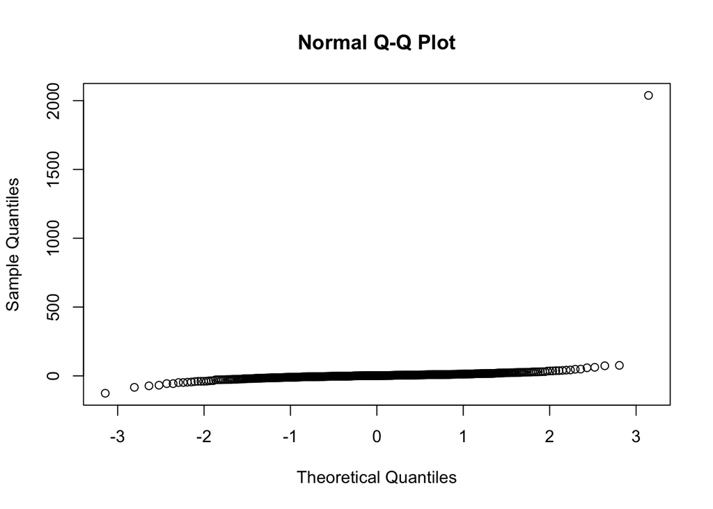

```r
SPX <- as.data.frame(getSymbols("^GSPC",auto.assign = FALSE, from = "2016-01-01"))
SPX <- setDT(SPX, keep.rownames = TRUE)
colnames(SPX)[1] <- c("Date")
sp500 <- SPX %>% select(Date, GSPC.Open)
sp500self <- sp500$GSPC.Open
lenminusone <- length(sp500self)-1
laggedsp500 <- c(0, sp500self[0:lenminusone])
diff <- sp500self - laggedsp500
sp500 <- sp500 %>% mutate(diff = ifelse(diff > 0, 1, 0))
qqnorm(diff)
```

```r
pca_x = data.frame(pcacmp$x) %>% select(PC1:PC20)
pca_x$Date = firstdata$Date

sp500$Date <- as.Date(sp500$Date)
traindata <- sp500 %>% inner_join(pca_x, by = "Date") %>% select(diff, PC1:PC20)

htrain = as.h2o(traindata)
hglm = h2o.glm(y = "diff", training_frame = htrain, family = "binomial", nfolds = 5)
h2o.confusionMatrix(hglm)
```

```
## Confusion Matrix (vertical: actual; across: predicted)  for max f1 @ threshold = 0.482108263469721:
##         0  1    Error     Rate
## 0      27 25 0.480769   =25/52
## 1       7 67 0.094595    =7/74
## Totals 34 92 0.253968  =32/126
```

## Q9

it seem’s that 412 is the best number for number of principal components.

```r
library(jpeg)
pic = flip(readImage("~/Desktop/download.jpeg"))
r <- pic[,,1]
g <- pic[,,2]
b <- pic[,,3]
picred <- prcomp(r, center = FALSE)
picgreen <- prcomp(g, center = FALSE)
picblue <- prcomp(b, center = FALSE)
rgb.pca <- list(picred,picgreen, picblue)
for (i in 1:412) {
  pca.img <- sapply(rgb.pca, function(j) {
    compressed.img <- j$x[,1:i] %*% t(j$rotation[,1:i])
  }, simplify = 'array')
  writeJPEG(pca.img, paste('~/Documents/Data Analysis/HW9/Pics/', round(i,0), '_components.jpg', sep = ''))
}

file.info("~/Desktop/download.jpeg")$size / 1000
```

```
## [1] 117.578
```

```r
sizes <- c()
for (i in 1:412) {
  full.path <- paste('~/Documents/Data Analysis/HW9/Pics/', round(i,0), '_components.jpg', sep = '')
  size <- file.info(full.path)$size / 1000
  sizes <- c(sizes,size)
}
sizes <- data.frame(sizes)
sizes <- cbind(1:412,sizes)
colnames(sizes) <- c("n","size")
hchart(sizes, "line",hcaes(x= n ,y = size))
```

[interactive chart not shown]

## Q10

First: Finding the company with biggest turnover Second: Finding the sector with biggest turnover Third: Study the changes in Computer companies stock during these years Forth: which companies lost their stock during these years and why Fifth: Is there any specific month or any interval of year which there is significant change in turnover?